# Kaplan Meier Curves in R using SAS Output

Matthew Kumar

October 10, 2019

This guide will demonstrate how to construct Kaplan Meier curves in R using SAS generated output.

# Kaplan Meier Analysis in SAS

We’ll use the `BMT` dataset that is available in the `SASHELP` library for demonstration purposes.

The following SAS code performs the analysis and saves the necessary output needed to construct the curve.

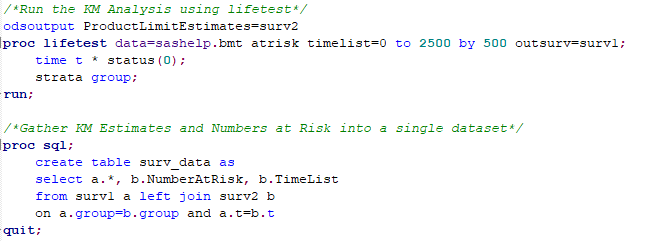

You then need to export the `surv_data` dataset - I recommend using something simple (e.g. CSV).

# R Prerequisites

## Packages

You will need the following packages installed in your R environment.

```r
library(tidyr)
library(dplyr)
library(ggplot2)
```

## Data Management

The first step is to import and verify the contents of the data set generated by SAS.

```r
surv <- read.csv("surv_data.csv", header=T)
str(surv)
```

```
#> 'data.frame':    144 obs. of  9 variables:
#>  $ Group       : Factor w/ 3 levels "ALL","AML-High Risk",..: 1 1 1 1 1 1 1 1 1 1 ...
#>  $ T           : int  0 1 55 74 86 104 107 109 110 122 ...
#>  $ X_CENSOR_   : int  NA 0 0 0 0 0 0 0 0 0 ...
#>  $ SURVIVAL    : num  1 0.974 0.947 0.921 0.895 ...
#>  $ SDF_LCL     : num  1 0.828 0.806 0.775 0.743 ...
#>  $ SDF_UCL     : num  1 0.996 0.987 0.974 0.959 ...
#>  $ STRATUM     : int  1 1 1 1 1 1 1 1 1 1 ...
#>  $ NumberAtRisk: int  38 NA NA NA NA NA NA NA NA NA ...
#>  $ Timelist    : num  0 NA NA NA NA NA NA NA NA NA ...
```

By default, SAS does not carry forward survival estimates across time. Fortunately this is straight forward to modify in R.

```r
surv = surv %>% tidyr::fill(SURVIVAL)
```

# Basic KM Curves in R

The following code will construct a basic Kaplan Meier curve using `ggplot2`. You can of course apply any other ggplot-specific customizations too.

**Note**: The `scale_x_continuous` arguement should be consistent with whatever you specified in the initial SAS code.

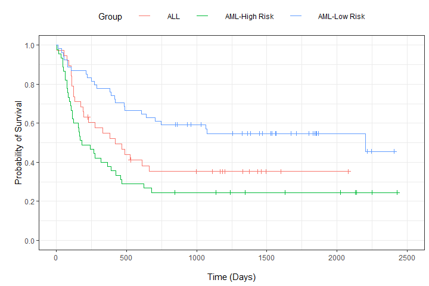

```r
km <- ggplot(surv, aes(group=Group, y=SURVIVAL,x=T,colour=Group)) +
      geom_step() +
      geom_point(show.legend=FALSE, aes(shape=as.factor(X_CENSOR_))) +
      scale_shape_manual("", values=c(32,3)) +
      scale_y_continuous(breaks=seq(0,1,0.2),    limits=c(0,1)   ) +
      scale_x_continuous(breaks=seq(0,2500,500), limits=c(0,2500)) +
      xlab("\nTime (Days)") +
      ylab("\nProbability of Survival") +
      theme_bw() +
      theme(legend.position="top",legend.spacing.x = unit(.7, 'cm'))
km
```

To export the image to a high-res graphic, you can use `ggsave`

```r
ggsave("basic_km.pdf", width=12, height=6)
```

That’s it!

# Advanced KM Curves in R

## Numbers at Risk

To add the numbers at risk table, we’ll need to create another plot object.

**Note**: The `scale_x_continuous` arguement should be consistent with whatever you specified in the initial SAS code.

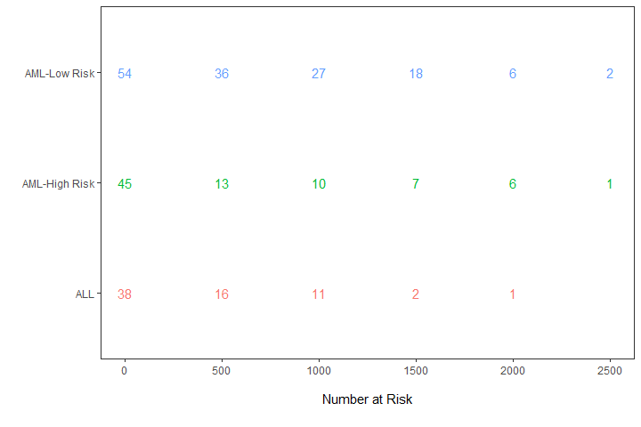

```r
atrisk <- ggplot(subset(surv, !is.na(NumberAtRisk)), aes(color=Group)) +
  geom_text(aes(label=NumberAtRisk, x=Timelist,y=Group), show.legend=FALSE) +
  scale_x_continuous(breaks=seq(0,2500,500), limits=c(0,2500)) +
  ylab("") +
  xlab("\nNumber at Risk\n") +
  theme_bw() +
  theme(panel.grid.major = element_blank(), panel.grid.minor = element_blank())
atrisk
```

To assemble both plots into a single plot, we can use `patchwork`. You will need to install it from github as it is currently not available through CRAN.

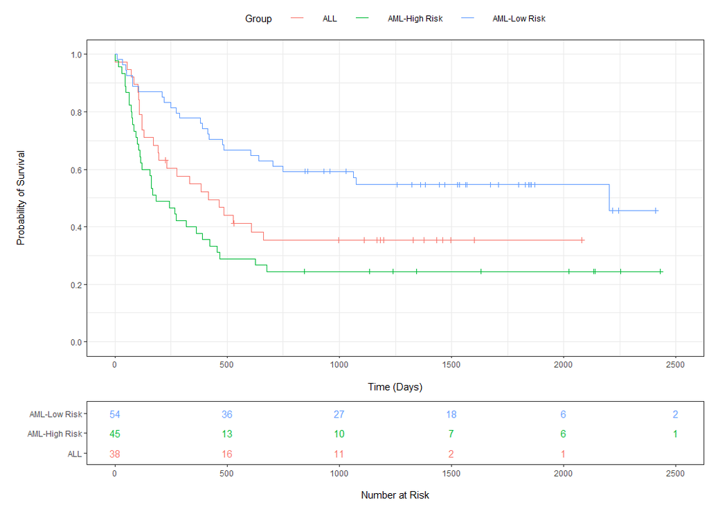

```r
#install.packages("devtools")
#devtools::install_github("thomasp85/patchwork")

library(patchwork)

km2 <- km + atrisk + plot_layout(ncol=1, heights=c(1,0.20))
km2
```

```r
ggsave("adv_km.pdf", width=12, height=6)
```

# Themes

The `ggthemr` package is used here to demonstrate adding themes to the Kaplan Meier plot. It can also be installed from github.

```r
#devtools::install_github('cttobin/ggthemr')
library(ggthemr)
```

Here are some examples. Note that I removed `theme_bw()` arguements from the code below.

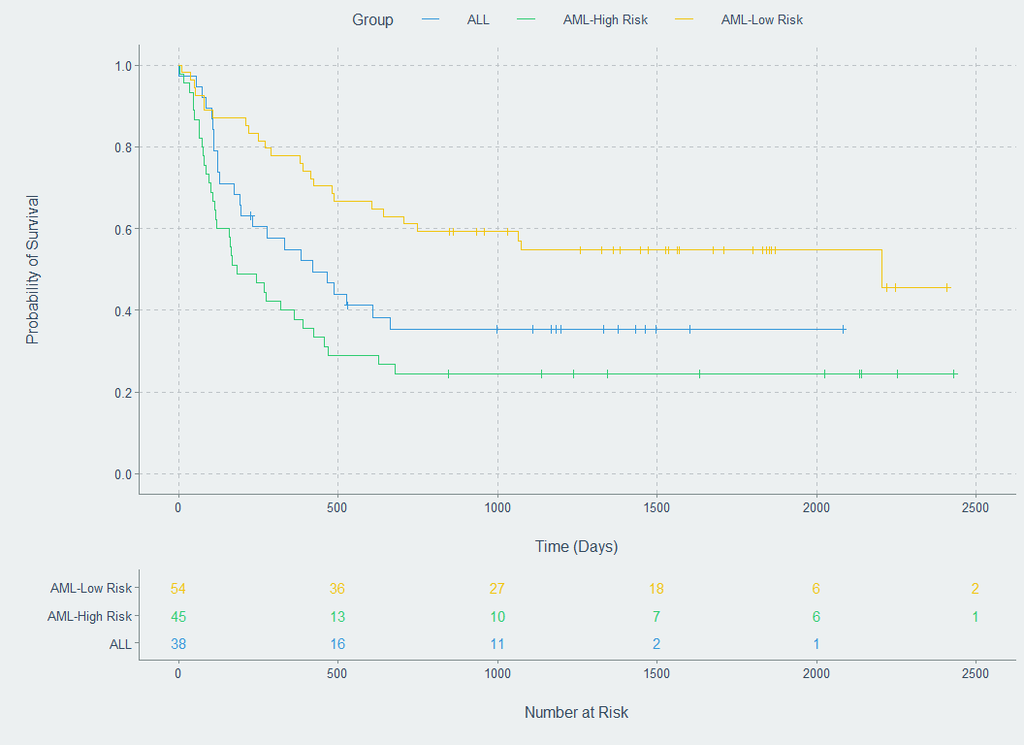

```r
ggthemr('flat', type = 'outer')

km <- ggplot(surv, aes(group=Group, y=SURVIVAL,x=T,colour=Group)) +
      geom_step() +
      geom_point(show.legend=FALSE, aes(shape=as.factor(X_CENSOR_))) +
      scale_shape_manual("", values=c(32,3)) +
      scale_y_continuous(breaks=seq(0,1,0.2),    limits=c(0,1)   ) +
      scale_x_continuous(breaks=seq(0,2500,500), limits=c(0,2500)) +
      xlab("\nTime (Days)") +
      ylab("\nProbability of Survival") +
      theme(legend.position="top",legend.spacing.x = unit(.7, 'cm'))

atrisk <- ggplot(subset(surv, !is.na(NumberAtRisk)), aes(color=Group)) +
        geom_text(aes(label=NumberAtRisk, x=Timelist,y=Group), show.legend=FALSE) +
        scale_x_continuous(breaks=seq(0,2500,500), limits=c(0,2500)) +
        ylab("") +
        xlab("\nNumber at Risk\n") +
        theme(panel.grid.major = element_blank(), panel.grid.minor = element_blank())


eg1 <- km + atrisk + plot_layout(ncol=1, heights=c(1,0.20))
eg1
```

Here are some others.

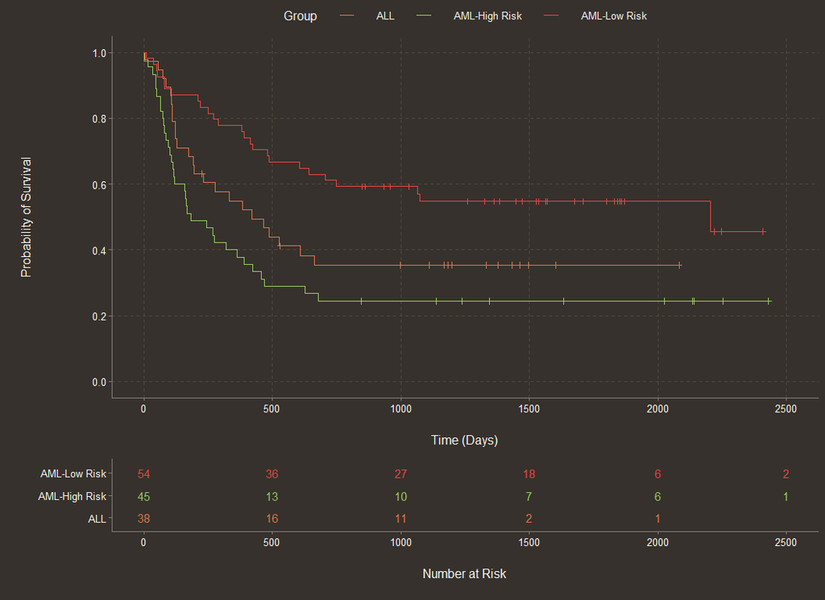

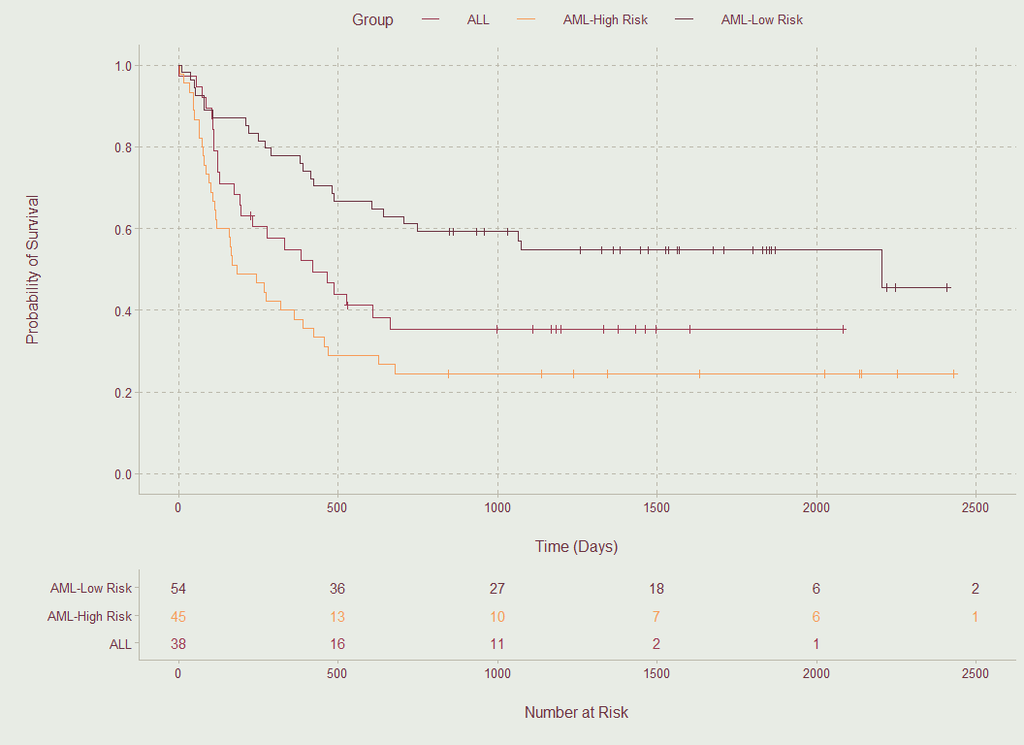

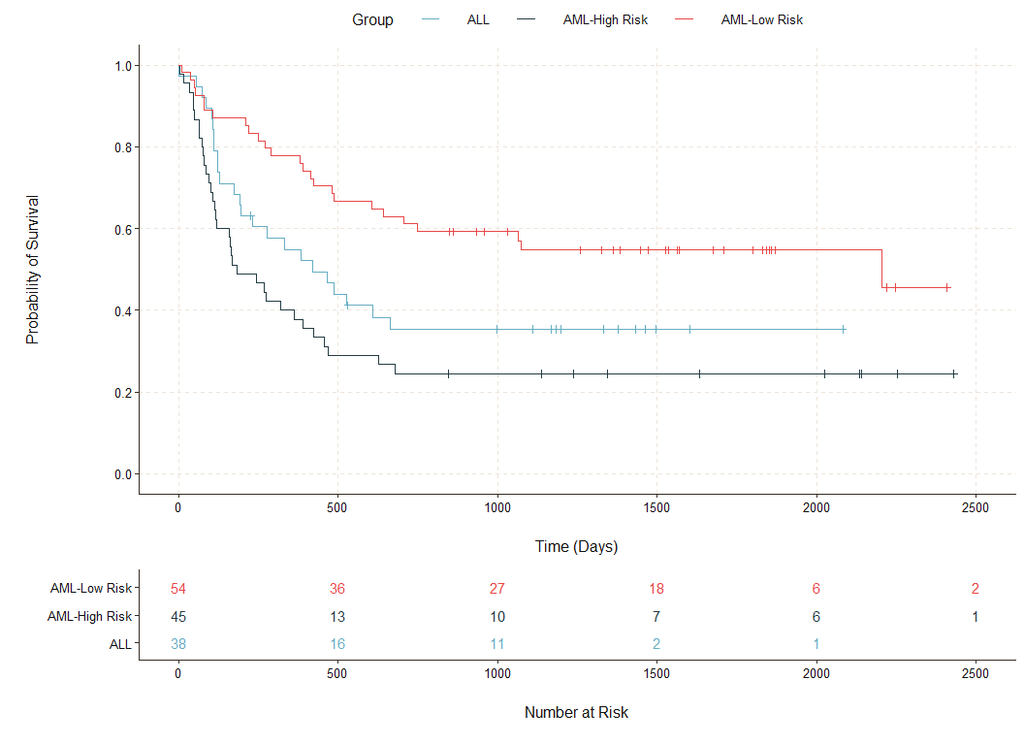

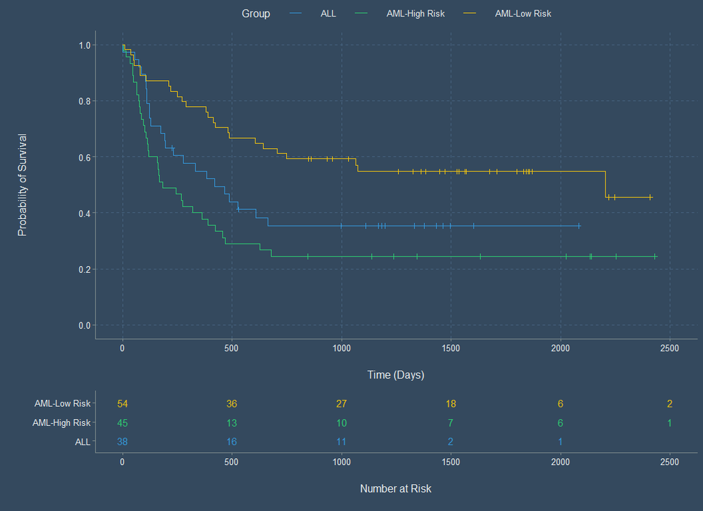